# week3 lab

J.F.P. (Richard) Scholtens s2956586

Generation date: feb 22, 2019 - 01:08:28

Compare intuitions of non-linguists vs geographic distances for Dutch dialects.

Source: Van Bezooijen & Heeringa (2006)

Intuitive distance: rate the dialect distance compared to standard Dutch per province: 0= equal to the standard, 100=maximum distance.

Geographic distance between provinces and standard Dutch. · · Standard Dutch located at the position of Haarlem.

Distances between the geographic centers of the provinces and Haarlem measured asthe-crow-ies and scaled to the range [0, 100].

# 1 Load data

Create the 2 vectors for our numerical variables: intuitive distance and geographic distance.

```r
int_dist <- c(57,55,58,58,56,50,39,40,20,18,34,17,22,41,51,72,57)
geo_dist <- c(100,89,90,88,85,70,59,52,23,25,52,14,40,67,79,62,95)
```

# 2 Scatter Plot

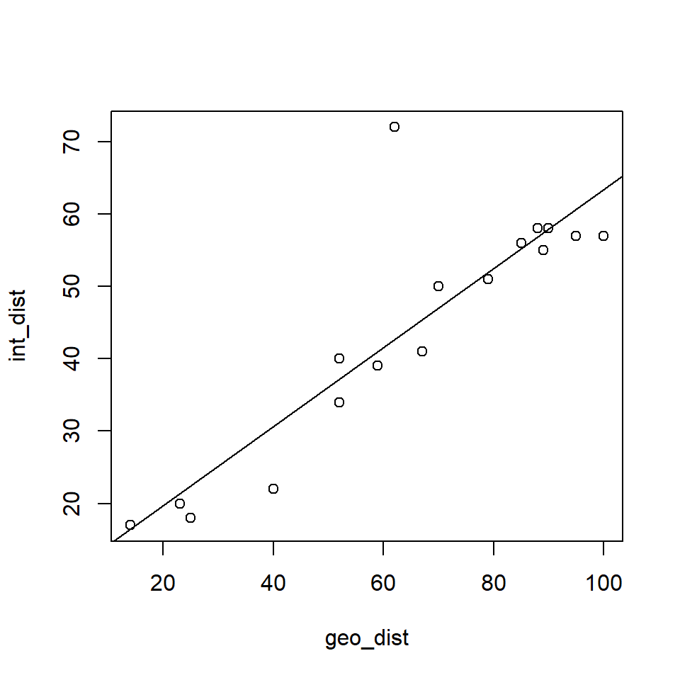

```r
plot(int_dist ~ geo_dist) # scatter plot of the correlation
m <- lm(int_dist ~ geo_dist); abline(m) # regression line
```

We see a line which moves from left down to right top. This indicates there is a positive correlation between intuitive and geographic distance because the high values tend to correspond to high values of the other variable.

# 3 Pearson

```r
cor.test(int_dist, geo_dist, method="pearson", alternative="greater")
```

```
##
##  Pearson's product-moment correlation
##
## data:  int_dist and geo_dist
## t = 6.9078, df = 15, p-value = 2.498e-06
## alternative hypothesis: true correlation is greater than 0
## 95 percent confidence interval:
##  0.7176751 1.0000000
## sample estimates:
##      cor
## 0.872257
```

After reviewing the scatter plot I believe that there is a positive relationship between the intuïtive and geographical distance. Therefor I’ve come up with the following hypotheses.

$H_0$ = There is no relationship between intuitive and geographical distance.

$H_a$ = There is a positive relationship between intuïtive and geographical distance.

df = 15 P-level = 2.498e-06 Correlation = 0.872257

The p-level is below the significancelevel of 0.001 and therefor we must reject $H_0$ and accept $H_a$.

# 4 Assumptions Parametric Correlation

Assumption 1: The sample is randomly selected from the population it represents

The distances are randomly selected by the teacher. This assumption is met.

Assumption 2:Both variables are at least interval-scaled

The variables are ratio-scaled. This assumption is met.

Assumption 3: Both variables come from a bivariate normal distribution and/or the sample size is large (30 and more observations).

$H_0$ = The intuitive and geographical distances are normally distributed.

$H_a$ = The intuitive and geographical distances are not normally distributed.

```r
library('energy')
mvnorm.etest(cbind(int_dist, geo_dist), R=999)
```

```
##
##  Energy test of multivariate normality: estimated parameters
##
## data:  x, sample size 17, dimension 2, replicates 999
## E-statistic = 1.4779, p-value = 0.002002
```

The p-level is lower than the significance level of 0.01. Therefor we reject $H_0$ and accept $H_a$. This means the both variables are not bivariate normally distributed.

This assumption is not met and therefor we must use a non-parametric test.

Assumption 4: The residual (error) variance is homoscedastic (homo is ‘same’ and scedastic comes from ‘scatter’).

$H_0$ = The error variance is homoscedastic.

$H_a$ = The error variance is not homoscedastic.

```r
library('car')
ncvTest(m)
```

```
## Non-constant Variance Score Test
## Variance formula: ~ fitted.values
## Chisquare = 0.07150393    Df = 1     p = 0.7891595
```

Chisquare = 0.07150393

Df = 1

P-level = 0.7891595

The p-level is higher than the significance level of 0.01. Therefor we cannot reject $H_0$. This means the error variance is homoscedastic. This assumption is met.

Assumption 5: The residuals are independent.

$H_0$ = The is no autocorrelation between residuals.

$H_a$ = The is autocorrelation between residuals.

```r
durbinWatsonTest(m)
```

```
##  lag Autocorrelation D-W Statistic p-value
##    1     -0.07105993      2.091171   0.886
##  Alternative hypothesis: rho != 0
```

D-W Statistic = 2.091171

The p-level is higher than the significance level of 0.01. Therefor we cannot reject $H_0$. This means there is no autocorrelation between residuals. This assumption is met.

Conclusion Assumptions:

Because both variables are not bivariate normally distributed we must use a non-parametric correlation test.

# 5 Non-parametric test

$H_0$ = There is no relationship between intuitive and geographical distance.

$H_a$ = There is a positive relationship between intuïtive and geographical distance.

```r
cor.test(int_dist, geo_dist, method="spearman", alternative="greater")
```

```
##
##  Spearman's rank correlation rho
##
## data:  int_dist and geo_dist
## S = 123.73, p-value = 8.4e-06
## alternative hypothesis: true rho is greater than 0
## sample estimates:
##       rho
## 0.8483734
```

```r
cor.test(int_dist, geo_dist, method="kendall", alternative="greater")
```

```
##
##  Kendall's rank correlation tau
##
## data:  int_dist and geo_dist
## z = 4.0884, p-value = 2.171e-05
## alternative hypothesis: true tau is greater than 0
## sample estimates:
##       tau
## 0.7360646
```

Spearman:

rho = 0.8483734 P-level = 8.4e-06

The p-level is lower than the significance level of 0.01. Therefor we reject $H_0$ and accept $H_a$. This means there is a positive relationship between intuitive and geographical distance.

Kendall:

tau = 0.7360646 P-level = 2.171e-05

The p-level is lower than the significance level of 0.01. Therefor we reject $H_0$ and accept $H_a$. This means there is a positive relationship between intuitive and geographical distance.

# 6 Non-parametric test, which to use?

Because of the small dataset it is better to use the Kendall test because it yields less extreme values.

# 7 Assumptions Non-Parametric Correlation

Assumption 1: The sample is randomly drawn from the population. This means that the subjects were selected randomly.

This assumption is met.

Assumption 2: Both variables are on the ordinal scale of measurement. If they are interval- or ratioscaled, they will be transformed to ranks by R automatically.

The variables are ratio-scaled and therefor the assumption is met.

Conclusion:

Both assumptions are met for the non-parametric correlation tests.

# 8 Check Outliers

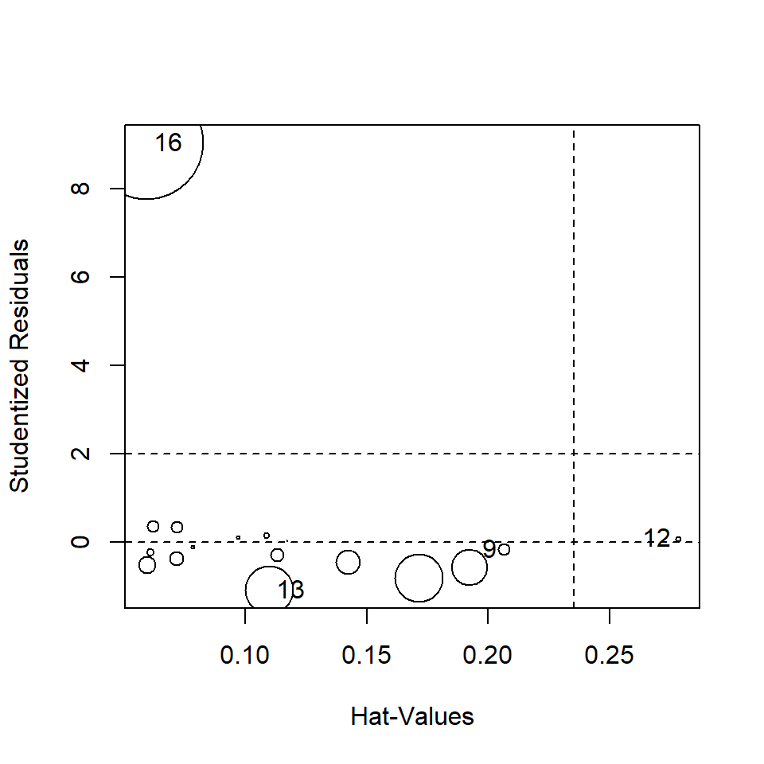

```
##        StudRes        Hat       CookD
## 9  -0.17773883 0.20661161 0.004397318
## 12  0.07115721 0.27838911 0.001046076
## 13 -1.09329199 0.10966906 0.072670364
## 16  9.04283854 0.05921553 0.403063575
```

```r
influencePlot(m, id.method = "identify")
```

I would remove datapoint 16 and 12 because of this:

The studentized residual of datapoint 16 is higher than 2. The range is -2 to 2. This means there is a high discrepancy between the actual and fitted value.

Datapoint 12 has more than twice the average hat value. There for it is better to remove because it has a high influence on the fitted values.

Also the Cook distance of datapoint 16 is high. This means it has a high effect if removed.

# 9 Linear regression

```r
summary(lm(int_dist ~ geo_dist))
```

```
##
## Call:
## lm(formula = int_dist ~ geo_dist)
##
## Residuals:
##     Min      1Q  Median      3Q     Max
## -8.6611 -3.6778 -1.3832  0.7797 29.3322
##
## Coefficients:
##             Estimate Std. Error t value Pr(>|t|)
## (Intercept)  8.83076    5.46459   1.616    0.127
## geo_dist     0.54576    0.07901   6.908    5e-06 ***
## ---
## Signif. codes:  0 '***' 0.001 '**' 0.01 '*' 0.05 '.' 0.1 ' ' 1
##
## Residual standard error: 8.45 on 15 degrees of freedom
## Multiple R-squared:  0.7608, Adjusted R-squared:  0.7449
## F-statistic: 47.72 on 1 and 15 DF,  p-value: 4.995e-06
```

```r
confint(lm(int_dist ~ geo_dist))
```

```
##                  2.5 %     97.5 %
## (Intercept) -2.8167406 20.4782515
## geo_dist     0.3773608  0.7141569
```

b0 = 8.83076

P-level = 0.127

The p-level is above the significance level and therefor not significant.

Confidence interval range is between -2.8167406 and 20.4782515.

b1 = 0.54576

P-level = 5e-06

Confidence interval range is between 0.3773608 and 0.7141569.

# 10 Plot with confidence region

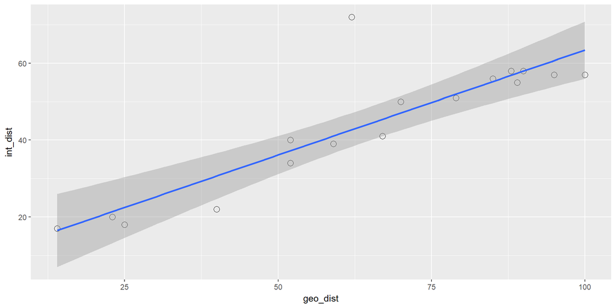

```r
library(ggplot2)
data <- data.frame(int_dist, geo_dist)
ggplot(data, aes(x=geo_dist, y=int_dist)) + geom_point(shape=1, size=3) + stat_smooth(method = lm)
```